# Read the data

## Adversarial Validation

The main idea of adversarial validation is to detect shift/drift in the different features between 2 datasets.

We usually train a model on past data to forecast future data so it can happened that these futures datas have a distribution that is no longer in line with the data we used for training, or maybe we train on some hospital datas and apply our model on other hospital ?

You can detect drift by statistical test (like t-test) but here we will do it by training a machine learning model and check if the model can figure out if the data is from the train or test set. If it can, this means that the test data comes from another distribution compare to the train data and then you have to check the distribution of the most important features that are likely to be different between train and test.

```python
def adversarial_validation(train, test, features):
    tr_data   = train.copy()
    tst_data = test.copy()
    tr_data['target']  = 0
    tst_data['target'] = 1
    av_data = pd.concat([tr_data, tst_data], axis = 0)
    av_data.reset_index(drop = True)
    params = {
            'learning_rate': 0.1,
            'seed': 50,
            'objective':'binary',
            'boosting_type':'gbdt',
            'metric': 'auc',
        }
    # define a KFold strategy
    kf = StratifiedKFold(n_splits = 5, shuffle=True, random_state=42)
    target = 'target'
    oof_pred = np.zeros(len(av_data))
    important_features = pd.DataFrame()
    fold_auc = []

    for fold, (tr_ind, val_ind) in enumerate(kf.split(av_data, av_data[target])) :
        print('Fold {}'.format(fold + 1))
        x_train, x_val = av_data[features].iloc[tr_ind], av_data[features].iloc[val_ind]
        y_train, y_val = av_data[target].iloc[tr_ind], av_data[target].iloc[val_ind]
        train_set = lgb.Dataset(x_train, y_train)
        val_set   = lgb.Dataset(x_val, y_val)

        model = lgb.train(params, train_set, num_boost_round = 1000, early_stopping_rounds = 20, valid_sets = [train_set, val_set], verbose_eval = 100)

        fold_importance = pd.DataFrame()
        fold_importance['feature'] = features
        fold_importance['gain'] = model.feature_importance()
        important_features = pd.concat([important_features, fold_importance], axis = 0)

        oof_pred[val_ind] = model.predict(x_val)
        fold_auc.append(metrics.roc_auc_score(y_train, model.predict(x_train)))

    print('Our mean train roc auc score is :', np.mean(fold_auc))
    print('Our oof roc auc score is :', metrics.roc_auc_score(av_data[target], oof_pred))
    return important_features
```

```python
# run the adversatial model with all the feature we used :

adversarial_features = adversarial_validation(train, test, features)
```

```
Fold 1
Training until validation scores don't improve for 20 rounds
Early stopping, best iteration is:
[8]	training's auc: 0.999923	valid_1's auc: 0.999668
Fold 2
Training until validation scores don't improve for 20 rounds
Early stopping, best iteration is:
[6]	training's auc: 0.999903	valid_1's auc: 0.999739
Fold 3
Training until validation scores don't improve for 20 rounds
Early stopping, best iteration is:
[20]	training's auc: 0.999975	valid_1's auc: 0.999695
Fold 4
Training until validation scores don't improve for 20 rounds
Early stopping, best iteration is:
[9]	training's auc: 0.999933	valid_1's auc: 0.999701
Fold 5
Training until validation scores don't improve for 20 rounds
Early stopping, best iteration is:
[42]	training's auc: 0.999998	valid_1's auc: 0.999744
Our mean train roc auc score is : 0.9999464223517089
Our oof roc auc score is : 0.9993863701821477
```

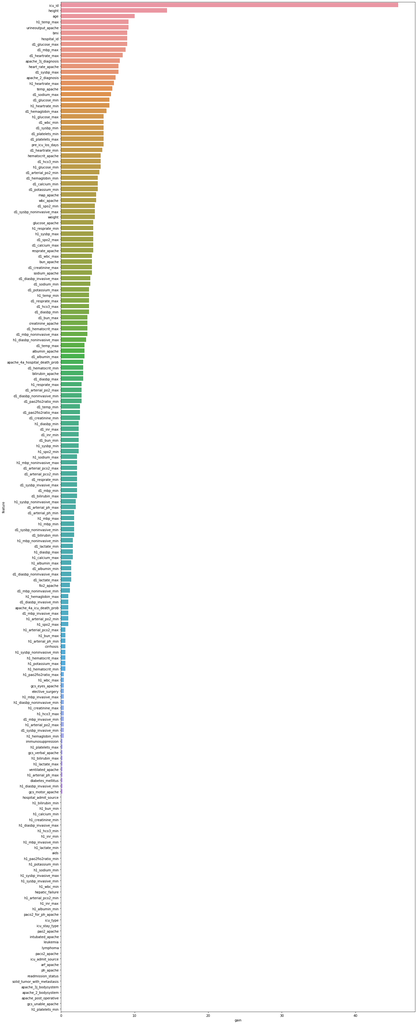

```python
# AUC is almost perfect so we can expect that some feature are perfectly different between train / test

adversarial_features = adversarial_features[['gain', 'feature']].groupby('feature').mean().reset_index()
adversarial_features= adversarial_features.sort_values('gain', ascending=False)

plot_importances(adversarial_features, 'importances-lgb-v5')
```

```
icu_id 0 gain : 45.8
```

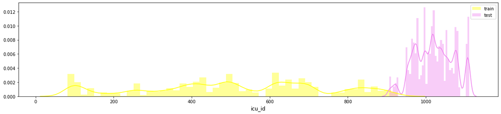

```
height 1 gain : 14.4
```

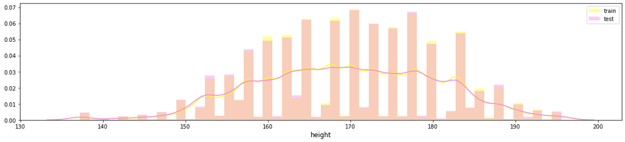

```
age 2 gain : 10.0
```

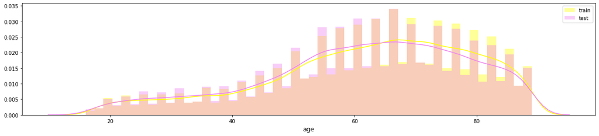

```
h1_temp_max 3 gain : 9.2
```

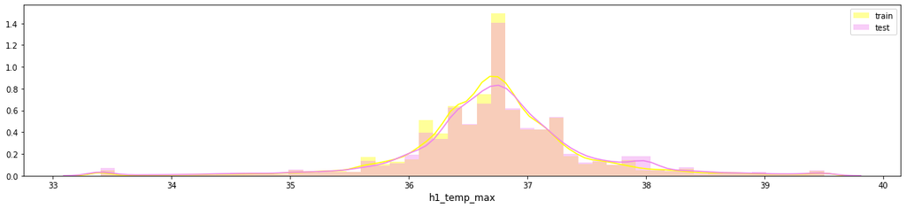

```
urineoutput_apache 4 gain : 9.2
```

```
bmi 5 gain : 9.0
```

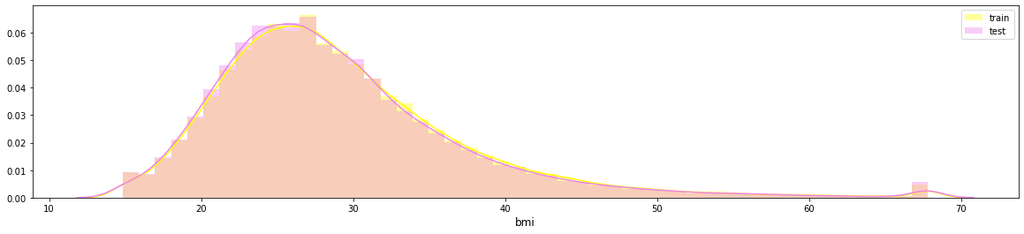

```
hospital_id 6 gain : 9.0
```

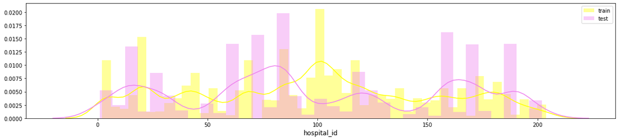

```
d1_glucose_max 7 gain : 9.0
```

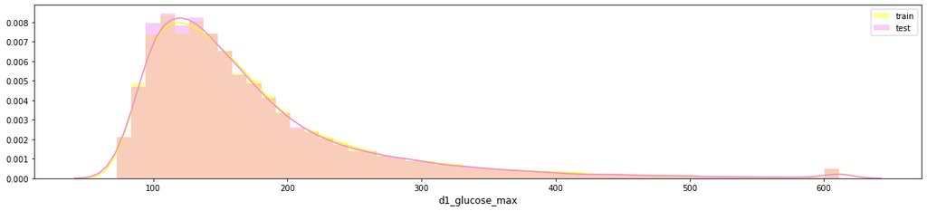

```
d1_mbp_max 8 gain : 8.8
```

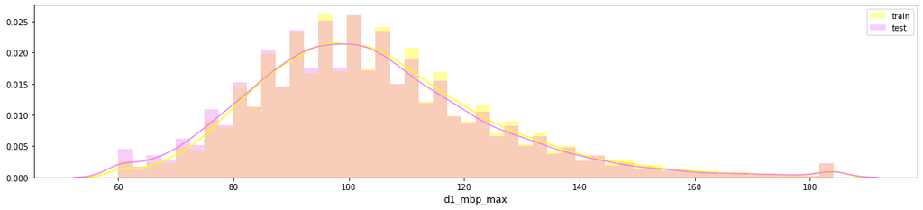

```
d1_heartrate_max 9 gain : 8.4
```

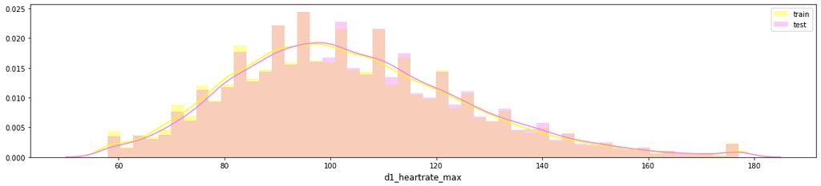

```python
# So icu_id columns seems to be the feature that dominate the feature importance for the adversarial
# validation model, so it is likely to be totally different between train and test,
# lets check the distribution of the top features :

def plot_differente_between_train_test(adversarial_features):
    import warnings
    warnings.filterwarnings("ignore")
    warnings.simplefilter(action='ignore', category=UserWarning)
    i=0
    for index, row in adversarial_features.sort_values(by=['gain'],ascending=False).iterrows():
        column=row['feature']
        if i< 10:
                print(column,i,"gain :",row['gain'])
                df1      = train.copy()
                df2      = test.copy()

                fig = plt.figure(figsize=(20,4))
                sns.distplot(df1[column].dropna(),  color='yellow', label='train', kde=True);
                sns.distplot(df2[column].dropna(),  color='violet', label='test', kde=True);
                fig=plt.legend(loc='best')
                plt.xlabel(column, fontsize=12);
                plt.show()
                i=i+1

plot_differente_between_train_test(adversarial_features)
```

```python
# it is .... Let's remove icu_id and see the results ..
adversarial_features2 = adversarial_validation(train, test, [ f for f in features if f not in ['icu_id'] ])
```

```
Fold 1
Training until validation scores don't improve for 20 rounds
[100]	training's auc: 0.999749	valid_1's auc: 0.999621
[200]	training's auc: 0.999992	valid_1's auc: 0.999654
Early stopping, best iteration is:
[198]	training's auc: 0.999991	valid_1's auc: 0.999655
Fold 2
Training until validation scores don't improve for 20 rounds
[100]	training's auc: 0.999745	valid_1's auc: 0.999567
Early stopping, best iteration is:
[114]	training's auc: 0.999813	valid_1's auc: 0.999578
Fold 3
Training until validation scores don't improve for 20 rounds
[100]	training's auc: 0.999733	valid_1's auc: 0.999673
Early stopping, best iteration is:
[125]	training's auc: 0.999845	valid_1's auc: 0.999689
Fold 4
Training until validation scores don't improve for 20 rounds
[100]	training's auc: 0.999753	valid_1's auc: 0.999655
Early stopping, best iteration is:
[159]	training's auc: 0.999963	valid_1's auc: 0.999671
Fold 5
Training until validation scores don't improve for 20 rounds
[100]	training's auc: 0.999742	valid_1's auc: 0.999696
Early stopping, best iteration is:
[97]	training's auc: 0.999723	valid_1's auc: 0.999699
Our mean train roc auc score is : 0.9998669344506522
Our oof roc auc score is : 0.9996579105906935
```

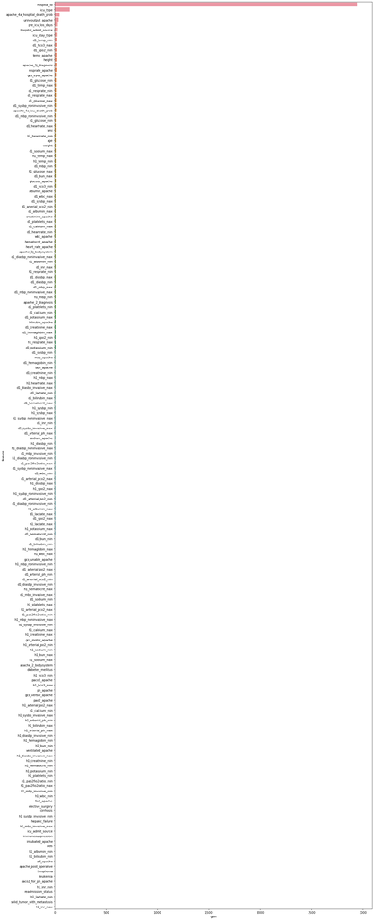

```python
# Let`s check again the difference between train / test

adversarial_features2 = adversarial_features2[['gain', 'feature']].groupby('feature').mean().reset_index()
adversarial_features2= adversarial_features2.sort_values('gain', ascending=False)

plot_importances(adversarial_features2, 'importances-lgb-v5')
```

```
hospital_id 0 gain : 2942.4
```

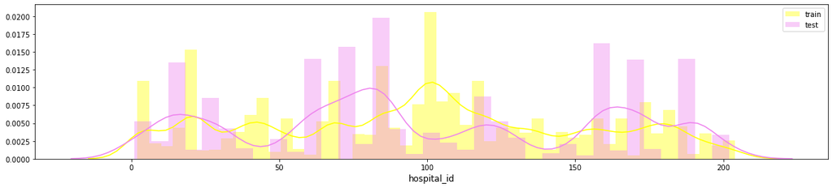

```
icu_type 1 gain : 147.0
```

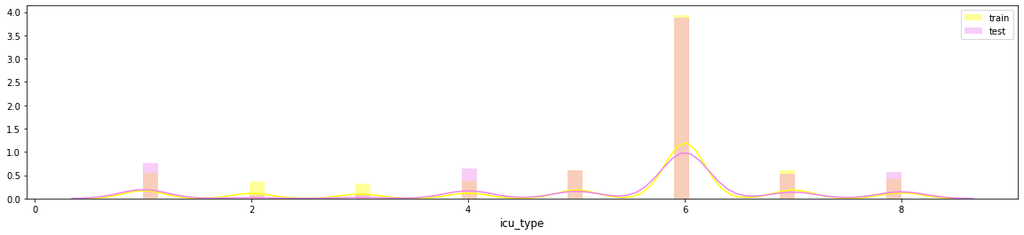

```
apache_4a_hospital_death_prob 2 gain : 48.2
```

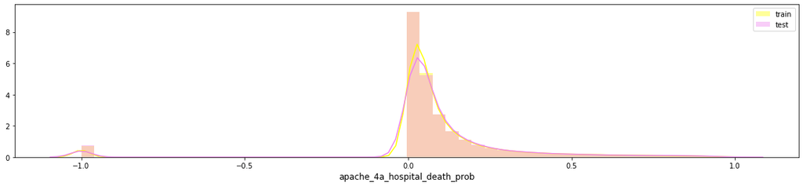

```
urineoutput_apache 3 gain : 39.8
```

```
pre_icu_los_days 4 gain : 30.4
```

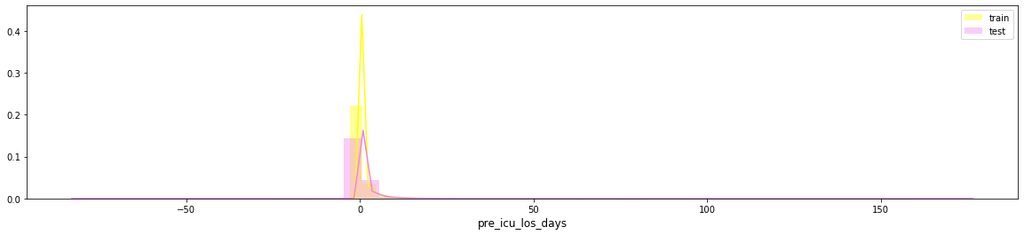

```
hospital_admit_source 5 gain : 29.6
```

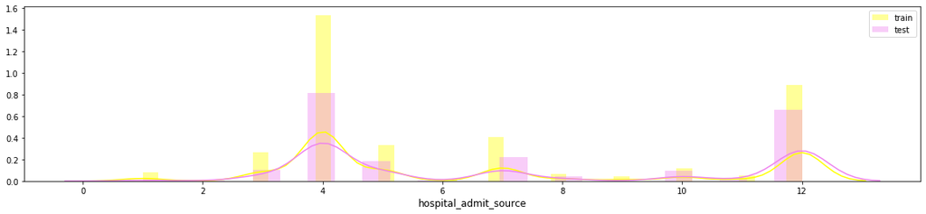

```
icu_stay_type 6 gain : 26.4
```

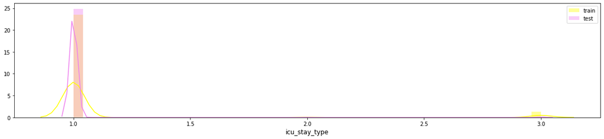

```
d1_temp_min 7 gain : 23.4
```

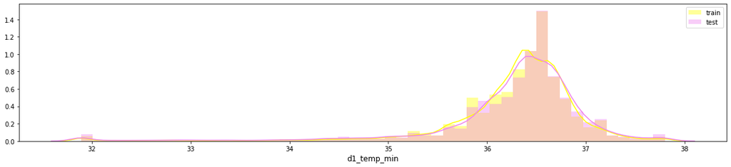

```
d1_hco3_max 8 gain : 22.6
```

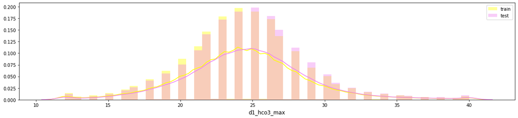

```
d1_spo2_min 9 gain : 21.8
```

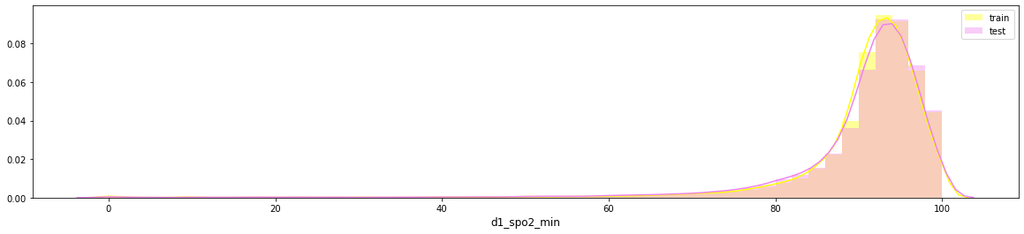

```python
plot_differente_between_train_test(adversarial_features2)
```